# Random Numbers Generation

## Random number generator

Random number generators (RNGs) are devices or programs that produce unpredictable and unbiased sequences of numbers.

## Why generate random numbers?

Random numbers can be used to:

- simulate different outcomes of an experiment
- generate secure keys to encrypt and decrypt data
- model different market scenarios, estimating the probability of occurrence of specific outcomes

## How can random numbers be generated?

- **hardware-based** generators - use physical phenomena such as thermal noise, radioactive decay, or quantum effects to generate random numbers
- **software-based** generators - algorithms that rely on mathematical equations to generate a sequence of numbers

## Good generators

A working definition of randomness in the context of computer-generated sequences is the following:

*Any two different random number generators ought to produce statistically the same results when coupled to your particular applications program. If they don’t, then at least one of them is not a good generator.*

## The random modules

There are several **methods** implemented in different languages to generate random numbers:

- *RandomNumberGenerator* class in C++ - provides many functions for generating random values, providing also various distributions such as normal, exponential, gamma
- *NativeCrypto* library in Android and iOS - provides cryptographically secure random values
- the *TrueRandom* Arduino library - create random numbers using external sources such atmospheric noise, or internal sources like ADC readings

Among the standard python libraries, we have access to 3 set of random functions generation:

- random
- numpy.random
- scipy.stats

## Random numbers and seeds

```python
import random

random.random()
```

```
0.016975968194491764
```

```python
[random.random() for i in range(3)]
```

```
[0.08353282471663426, 0.2920949791456978, 0.46275650293981374]
```

```python
[random.random() for i in range(3)]
```

```
[0.35730839539180914, 0.975316063490127, 0.5662443730010424]
```

```python
random.seed(42)
[random.random() for i in range(3)]
```

```
[0.6394267984578837, 0.025010755222666936, 0.27502931836911926]
```

```python
random.seed(42)
[random.random() for i in range(3)]
```

```
[0.6394267984578837, 0.025010755222666936, 0.27502931836911926]
```

## The linear congruential generator

A very simple way of generating random numbers (not a good one, but a good example) is the following:

$$R_{n+1} = (a \cdot R_n + c) \text{mod} m$$

where *a* is a positive integer called the multiplier, and *c* is a nonnegative integer called the increment.

For $c \neq 0$, the above equation is called a linear congruential generator (LCG).

```python
# values from the numerical recipies
m = 2**32
a = 1664525
c = 1013904223
```

```python
R0 = 4
R1 = (a*R0+c)%m
R1
```

```
1020562323
```

```python
for i in range(5):
    print(R1/m)
    R1 = (a*R1+c)%m
```

```
0.2376181825529784
0.6413819692097604
0.5583668493200094
0.8159323614090681
0.04994240193627775
```

```python
results = []
for i in range(5000):
    results.append(R1/m)
    R1 = (a*R1+c)%m
```

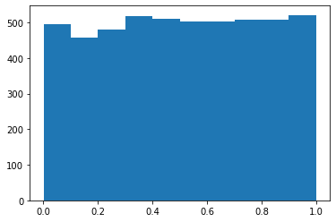

```python
plt.hist(results)
```

### Weakness of LCGs

If *k* random numbers at a time are used to plot points in k-dimensional space (with each coordinate between 0 and 1), then the points will not tend to “fill up” the k-dimensional space, but rather will lie on (k-1)-dimensional “planes.” There will be *at most* about $m^{1/k}$ such planes. If the constants **m** and **a** are not very carefully chosen, there will be *many fewer than that*.

```python
import scipy.stats as st
import pdir as dir

dir(st).properties.public
```

```
property:
    absolute_import, alpha, anglit, arcsine, argus, bernoulli, beta, betaprime, binom, boltzmann, bradford, burr, burr12, cauchy, chi, chi2, contingency, cosine, crystalball, dgamma, dirichlet, distributions, division, dlaplace, dweibull, erlang, expon, exponnorm, exponpow, exponweib, f, fatiguelife…
```

```python
dir(st.gamma).public
```

```
property:
    a, b, badvalue, extradoc, generic_moment, moment_type, name, numargs, shapes, vecentropy, xtol
descriptor:
    random_state: @property with getter, setter, Get or set the RandomState object for generating random variates.
function:
    cdf: Cumulative distribution function of the given RV.
    entropy: Differential entropy of the RV.
    expect: Calculate expected value of a function with respect to the
    fit: Return MLEs for shape (if applicable), location, and scale
    fit_loc_scale: Estimate loc and scale parameters from data using 1st and 2nd moments.
    freeze: Freeze the distribution for the given arguments.
    interval: Confidence interval with equal areas around the median.
    isf: Inverse survival function (inverse of `sf`) at q of the given RV.
    logcdf: Log of the cumulative distribution function at x of the given RV.
    logpdf: Log of the probability density function at x of the given RV.
    logsf: Log of the survival function of the given RV.
    mean: Mean of the distribution.
    median: Median of the distribution.
    moment: n-th order non-central moment of distribution.
    nnlf: Return negative loglikelihood function.
    pdf: Probability density function at x of the given RV.
    ppf: Percent point function (inverse of `cdf`) at q of the given RV.
    rvs: Random variates of given type.
    sf: Survival function (1 - `cdf`) at x of the given RV.
    stats: Some statistics of the given RV.
    std: Standard deviation of the distribution.
    var: Variance of the distribution.
```

All these distributions are described using a **location** and **scale** parameter, and, if necessary, one or more **shape** parameters.

Basically they can describe all translations and scalings of the basic function.

This is usually different from the traditional parametrization, and this can lead to some problems here and there.

```python
help(st.gamma.rvs)
```

```
Help on method rvs in module scipy.stats._distn_infrastructure:

rvs(*args, **kwds) method of scipy.stats._continuous_distns.gamma_gen instance
    Random variates of given type.

    Parameters
    ----------
    arg1, arg2, arg3,... : array_like
        The shape parameter(s) for the distribution (see docstring of the
        instance object for more information).
    loc : array_like, optional
        Location parameter (default=0).
    scale : array_like, optional
        Scale parameter (default=1).
    size : int or tuple of ints, optional
        Defining number of random variates (default is 1).
    random_state : {None, int, `~np.random.RandomState`, `~np.random.Generator`}, optional
        If `seed` is `None` the `~np.random.RandomState` singleton is used.
        If `seed` is an int, a new ``RandomState`` instance is used, seeded
        with seed.
        If `seed` is already a ``RandomState`` or ``Generator`` instance,
        then that object is used.
        Default is None.

    Returns
    -------
    rvs : ndarray or scalar
        Random variates of given `size`.
```

```python
dist = st.gamma(2.0, loc=0, scale=1)
data = dist.rvs(100)
```

```python
st.gamma.fit(data)
# alpha, location and scale
```

```
(2.233744749642886, 0.027371764377412493, 0.8645220289044107)
```

The parameter **location** is a shift, and it might not be appropriate for distributions like the gamma!

The fit method allow us to fix it to a certain value.

```python
st.gamma.fit(data, floc=0)
# alpha, location and scale
```

```
(2.3318138547265788, 0, 0.8399083174903061)
```

```python
params = st.gamma.fit(data, floc=0)
new_dist = st.gamma(*params)
```

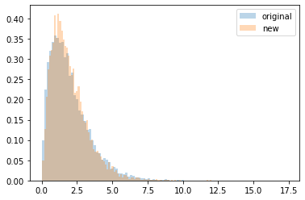

```python
plt.hist(dist.rvs(10000), bins=100, density=True, alpha=0.3, label='original')
plt.hist(new_dist.rvs(10000), bins=100, density=True, alpha=0.3, label='new')
plt.legend(loc='best')
```

## Inverse transform method

Inverse transform sampling is a method for generating random numbers from any probability distribution by using its inverse cumulative distribution $F^{−1}(x)$.

The cumulative distribution for a random variable $X$ is $F_{X}(x)=P(X≤x)$.

### Algorithm

We want to generate a random variable $X$ with cumulative distribution function (CDF) $F_{X}$.

The algorithm is simple:

- generate a sequence of random numbers $R$ between 0 and 1 drawn from a uniform distribution
- find $X=F^{-1}(R)$

For the **exponential** distribution, can write the following functions:

```python
def exp_pdf(x, b=1):
    return b*np.exp(-b*x)

def exp_cdf(x, b=1):
    return 1 - np.exp(-b*x)

def exp_inv_cdf(p, b=1):
    return -np.log(1-p)/b
```

```python
x = np.linspace(0,5,100)

r = np.random.random(10000)
exp_gen_r = exp_inv_cdf(r)
```

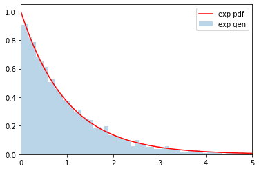

```python
plt.hist(exp_gen_r, bins=100, density=True, alpha=0.3, label='exp gen')
plt.plot(x, exp_pdf(x), 'r', label='exp pdf')
plt.xlim([0,5])
plt.legend(loc='best')
plt.show()
```

## Visualizing the ECDF (Empirical Cumulative Distribution Function)

Being able to describe the ECDF, even as an approximation, allow us to generate random numbers with an arbitrary complicated distribution.

```python
data = plt.randn(4)
data
```

```
array([-0.16455686, -2.18912298,  0.07361477, -0.54956244])
```

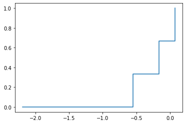

```python
data_sorted = np.sort(data)
index = np.linspace(0, 1, len(data_sorted))
plt.step(data_sorted, index, where='post')
plt.show()
```

To reduce the borders effect, it is better to adjust how we estimate the indexes.

```python
np.linspace(0, 1, 4)
```

```
array([0.        , 0.33333333, 0.66666667, 1.        ])
```

```python
np.linspace(0, 1, 4+1)
```

```
array([0.  , 0.25, 0.5 , 0.75, 1.  ])
```

```python
np.linspace(0, 1, 4+1)[1:]
```

```
array([0.25, 0.5 , 0.75, 1.  ])
```

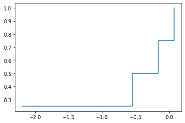

```python
data_sorted = np.sort(data)
index = np.linspace(0, 1, 1+len(data_sorted))[1:]

plt.step(data_sorted, index, where='post')
plt.show()
```

```python
def plot_ecdf(data, ax=None, **plot_kws):
    if ax is None:
        ax = plt.gca()
    data_sorted = np.sort(data)
    index = np.linspace(0, 1, 1+len(data_sorted))[1:]
    ax.step(data_sorted, index, where='post', **plot_kws)
```

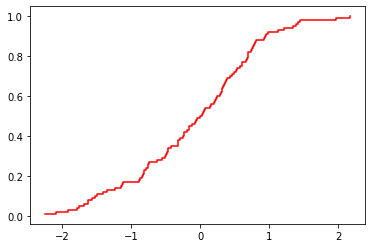

```python
plot_ecdf(plt.randn(100), color='r')
```

## What if we have data with unkown distribution?

Even if we have data with **unkonwn** distribution, we can still use the inverse transform method to create a random number generator.

In this case, the inverse CDF function can be estimated using interpolation.

```python
def compute_ecdf(data):
    data_sorted = np.sort(data)
    index = np.linspace(0, 1, 1+len(data_sorted))[1:]
    return data_sorted, index
```

```python
# create the data
x = np.concatenate([np.random.normal(2, 1, 10000), np.random.normal(5, 1, 10000)])
```

```python
from scipy.interpolate import interp1d

# apply the inverse transform method
ecdf_x, ecdf_y = compute_ecdf(x)
inverse_cdf = interp1d(ecdf_y, ecdf_x, bounds_error=False, assume_sorted=True)
r = np.random.uniform(0, 1, 1000)
gen_sample = inverse_cdf(r)
```

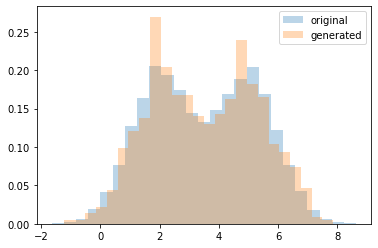

```python
# compare the original data distribution and the generated sample
plt.hist(x, bins=25, density=True, alpha=0.3, label='original')
plt.hist(gen_sample, bins=25, density=True, alpha=0.3, label='generated')
plt.legend(loc='best')
```

```python
# create the data
x = (5+plt.randn(100))**2
```

```python
# apply the inverse transform method
ecdf_x, ecdf_y = compute_ecdf(x)
inverse_cdf = interp1d(ecdf_y, ecdf_x, bounds_error=False, assume_sorted=True)
r = np.random.uniform(0, 1, 1000)
gen_sample = inverse_cdf(r)
```

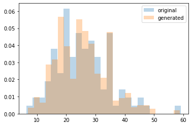

```python
# compare the original data distribution and the generated sample
plt.hist(x, bins=25, density=True, alpha=0.3, label='original')
plt.hist(gen_sample, bins=25, density=True, alpha=0.3, label='generated')
plt.legend(loc='best')
```

## Monte Carlo methods

A collection of methods that uses random sequences to estimate the average value of some specific functions, often integrals.

An example is the estimation of the value of $\pi$ using random numbers

$$ \int_{[0,1]^s} f(u)\,{\rm d}u \approx \frac{1}{N}\,\sum_{i=1}^N f(x_i). $$

The rate of convergence by using N random numbers is $O\left(\frac{1}{\sqrt{N}}\right)$.

The rate of convergence using a uniform sampling of N numbers is $O\left(\frac{1}{N}\right)$.

Sampling using random numbers converge more slowly, but can be performed for as long as we want until we reach the convergence up to a certain precision.

With uniformely sampled numbers, if the chosen sampling wasn't enough, we have to start from scratch and redo everything.

## Low-discrepancy sequences

There are better methods for exploring a function if we can, and that is by using **low-discrepancy sequences**.

These are sequences that look quite random, but do not tend to cluster as random numbers do, covering the space in a more uniform way.

The big advantage is that they keep having this property if we continue forward with the sequence of sampling.

Low-discrepancy sequences converge with $O\left(\frac{1}{N}\right)$, but they are a little more difficult to implement.

These methods are called quasi-Monte Carlo, as they are not using proper pseudo-random numbers

## Van der Corput sequence

The simplest low-discrepancy sequence is the **Van der Corput sequence**, and is quite easy to implement.

The denominators are increasing powers of the base, the numerators are all the values in that base, but sorted based on the last digit (skipping the numbers that ends in 0, as they would simplify and recreate previous ones)

$$\left\{ \tfrac{1}{10}, \tfrac{2}{10}, \tfrac{3}{10}, \tfrac{4}{10}, \tfrac{5}{10}, \tfrac{6}{10}, \tfrac{7}{10}, \tfrac{8}{10}, \tfrac{9}{10}, \tfrac{01}{100}, \tfrac{11}{100}, \tfrac{21}{100}, \tfrac{31}{100}, \tfrac{41}{100}, \tfrac{51}{100}, \tfrac{61}{100}, \tfrac{71}{100}, \tfrac{81}{100}, \tfrac{91}{100}, \tfrac{02}{100}, \tfrac{12}{100}, \tfrac{22}{100}, \tfrac{32}{100}, \ldots \right\}$$

```python
def vdc(n, base=2):
    vdc = 0
    denom = 1
    while n:
        denom *= base
        n, remainder = divmod(n, base)
        vdc += remainder / denom
    return vdc

def avdn(n, base=10):
    return np.array([vdc(i, base=base) for i in range(1, n+1)])
```

```python
avdn(11)
```

```
array([0.1 , 0.2 , 0.3 , 0.4 , 0.5 , 0.6 , 0.7 , 0.8 , 0.9 , 0.01, 0.11])
```

```python
avdn(11, base=2)
```

```
array([0.5   , 0.25  , 0.75  , 0.125 , 0.625 , 0.375 , 0.875 , 0.0625,
       0.5625, 0.3125, 0.8125])
```

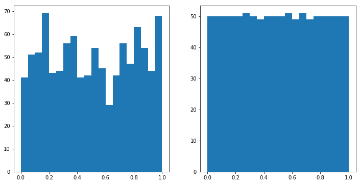

```python
fig, (ax1, ax2) = plt.subplots(1, 2, figsize=(12, 6))
bins = np.linspace(0, 1, 21)
ax1.hist(np.random.rand(1000), bins=bins)
ax2.hist(avdn(1000), bins=bins);
```

Being a uniform sample generator, one can then use this to generate arbitrary random variables!

For example, we can use it to generate normally distributed data.

To to that we can use the **isf** function.

```python
st.norm.isf(0.2)
```

```
0.8416212335729142
```

```python
st.norm.isf(0.9)
```

```
-1.2815515655446004
```

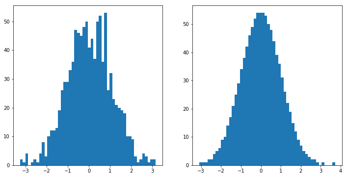

```python
fig, (ax1, ax2) = plt.subplots(1, 2, figsize=(12, 6))
ax1.hist(plt.randn(1000), bins=50)

vdn_sample = avdn(1000)
gaussian_samples = st.norm.isf(vdn_sample)
ax2.hist(gaussian_samples, bins=50)
```

The Van der Corput sequence can be generalized to multiple dimensions at the same time by the **Halton sequence**, that is generated in a similar fashion.

A general library to generate these sequences in high dimensions is provided by the library **SALib**.

You won't need it for today, but for real use, where the number of dimensions is high, it might be worth using it.

```python
from SALib.sample import saltelli
```

```python
problem = {
    'num_vars': 2,
    'names': ['x1', 'x2'],
    'bounds': [[0, 1],
               [0, 1],]
}
```

```python
param_values = saltelli.sample(problem, 100)
```

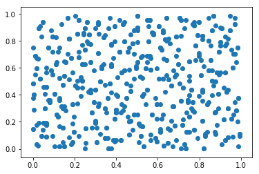

```python
plt.scatter(*param_values.T)
```

## Exercise

An interesting alternative is a low-discrepancy series [based on the golden ratio numbers](http://extremelearning.com.au/unreasonable-effectiveness-of-quasirandom-sequences/).

Try to implement it and compare it with the other methods seen today.